# Class 4: Value Proposition and Focus

MG106 Strategic Management

José Ignacio González Rojas

j.i.gonzalez-rojas@lse.ac.uk

London School of Economics and Political Science

June 26, 2026

## Airborne Express shows how focus can beat scale

**Can a smaller firm compete without matching the giants?**

In 1997, large incumbents dominate express mail. Airborne survives by choosing a narrower customer and aligning activities around that choice.

## Four questions structure today’s focus discussion

### Value proposition, focus, and activity fit explain Airborne’s position

#### Four questions for today

1. What changed in express mail?
2. Why did smaller, undifferentiated competitors struggle?
3. Which customers did Airborne choose to serve?
4. How did Airborne’s activities support its value proposition?

**Concept:** value proposition + focus + activity fit

**Task:** infer how each activity supports the chosen customer

**Start with the puzzle**

*How can a smaller firm compete without matching the giants?*

# Express mail became a scale-intensive industry

## Scale mattered more as service expectations and fixed costs rose

### Start-up conditions gave way to automated national systems

#### Early days: 1970s

- FedEx: 186 packages first night
- Simple hub operations
- Manual sorting
- Modest fixed costs
- Many small players viable

#### New reality: 1990s

- 5+ million packages daily
- $860M automated hubs
- $3B IT investments
- National advertising campaigns
- 3 players = >85% share

Which investments became mandatory?

## Scale competition created a reinforcing cost cycle

### Fixed costs rose because each giant matched the other

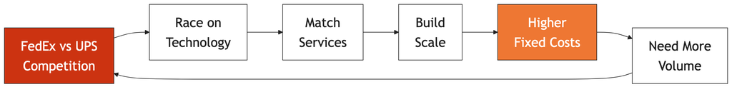

Where in the loop could a smaller firm refuse to compete?

## Head-to-head imitation required very large sunk investments

### The numbers explain why smaller firms struggled to copy the giants

**Hub automation**: UPS Louisville → **$860 million**

**Aircraft**: One Boeing 767 → **$90 million**

**IT catch-up**: UPS (1990-95) → **$3 billion**

**Annual advertising**: FedEx → **$138 million/year**

This makes head-to-head imitation difficult for smaller firms.

## The scale trap pushed undifferentiated small players out

### Competition can raise the cost of staying in the game

#### The pattern

1. Intense competition
2. Escalating investments
3. Higher sunk costs
4. Small players exit
5. Industry concentrates

#### The result

- 1970s: Many players
- 1997: Big 3 = >85% share
- Small players: exited, retreated, or marginalised

Competition raised the investment needed to stay comparable

Competition itself changed the industry structure

## FedEx and UPS converged despite different origins

### Two giants began with different organisational DNAs

#### FedEx (1973)

- Born in the air
- “Absolutely, positively overnight”
- Technology pioneer
- Empowerment culture
- Premium positioning

#### UPS (1907)

- Ground up heritage
- Efficiency obsession
- Time-motion studies
- Command & control
- Cost leadership

Competition pushed the two large players closer together.

## By 1997 the giants offered increasingly similar services

### Convergence made differentiation harder for followers

#### The convergence

- Products: Both offer overnight, 2-day, same-day
- Technology: Both have tracking, IT, guarantees
- Customers: Both chase consumer + business
- Pricing: both discount 50% off list

#### Only two differences remained

Culture (history) + Ground network (UPS only)

# Smaller competitors struggled when they stayed undifferentiated

## Smaller players were squeezed by scale and imitation pressure

### Case evidence shows retreat, exit, and marginalisation

#### Smaller competitors

- **Emery/Purolator**: Retreated to heavy cargo
- **BAX**: Pushed to periphery
- **Roadway Global Air**: Exit after hundreds of millions in losses
- **Others**: Marginal players at best

Operating margins? **Single digits**

#### Why they struggled

- Cannot match scale investments
- Price pressure from giants
- Service expectations rising
- No defensible position

Small + undifferentiated = no defensible position

## Cost and price exhibits explain Airborne’s narrow but viable position

### Airborne avoided some costs the giants had normalised

#### FedEx cost baseline

- Pickup, hub, long-haul, and delivery all mattered
- Advertising, sales, IT, service, and overhead added material cost
- The full-service system made scale investments mandatory

#### Airborne’s exhibit pattern

- Lower list prices on many core express products
- Selective service offer rather than full imitation
- Cost position depended on activity choices, not just discounts

Which costs did Airborne change, avoid, or accept?

## The scale disadvantage became self-reinforcing

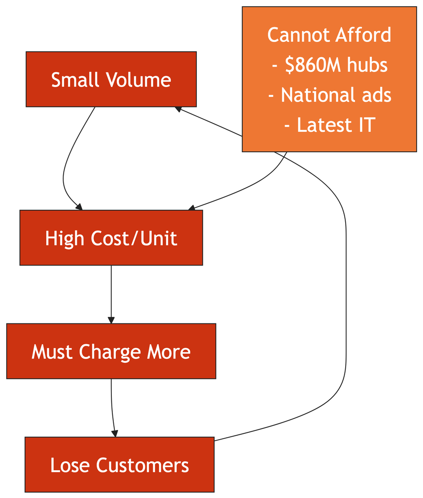

**The scale trap:** unless you find a different way to compete, lower volume raises unit cost.

# Airborne survived by choosing a narrower position

## Airborne prospered by avoiding head-to-head imitation

### A focused position made a difficult industry survivable

#### The numbers

- 16% market share
- Fastest growing for years
- Stock price doubling
- Profitable after a long adjustment period

#### The puzzle

How does a company **1/9th** the size of FedEx survive when others exit or retreat?

Identify the target customer before judging the activities.

**Hint:** it is not about competing head-to-head.

## Airborne’s customer focus meant saying no

### Focus is a positive choice and a refusal to serve some demand

#### Yes to

Large volume • Predictable • Dense routes • B2B • Price-sensitive

#### No to

Residential • Seasonal • Rural • Consumer • “Absolutely positively”

Why can serving demanding buyers work if Airborne serves them differently?

## Airborne’s activities reinforced its focused value proposition

### Each operating choice makes sense because of the customer choice

| **Activity** | **FedEx/UPS** | **Airborne** |
| --- | --- | --- |
| Aircraft | New planes | Used planes |
| Hub | Automated | Manual sort |
| Airport | Pay landing fees | **Own airport** |
| Delivery | Employees | **65% contractors** |
| Marketing | $138M ads | **Virtually no advertising** |
| Service | 10:30 AM | Noon delivery |

## The system logic is fit among choices, not one clever tactic

### Airborne’s choices work together

#### Each low-cost choice enables the others

- Predictable volume → Manual sort works
- B2B focus → No consumer ads needed
- Dense routes → Contractors reliable

**Result:** 30% by truck, 80% plane utilisation

*Copying one piece is not enough.*

## Airborne’s 20% cost edge supported its price proposition

### Lower average cost made discounting viable

1. **FedEx:** $8.55/letter → price: $9.00
2. **Airborne:** $6.88/letter → price: $7.20

**How:** contractors • 80% utilisation • no ads • lower overhead

But watch marginal costs…

# Airborne’s advantage also created vulnerabilities

## Airborne’s advantage came from focus, fit, and trade-offs

### The same choices that lower average cost can create marginal-cost risk

#### Cost advantages

Avoided fixed costs • variable > fixed • 80% utilisation

#### Strategic advantages

Customer fit • competitor trade-offs • system coherence

Which advantage disappears first if FedEx/UPS target Airborne’s segment?

## The vulnerability is the gap between average and marginal cost

### A low average cost position can still be weak in a price war

#### Average cost

Airborne wins by ~20%

- Spread fixed costs better
- Efficient operations

#### Marginal cost

Airborne may be **disadvantaged**

- Contractors cost more/package
- Old planes less fuel efficient
- Manual sorting labour-intensive

In a price war, Airborne is structurally disadvantaged.

**Implication:** Airborne is safest while FedEx/UPS ignore its segment.

## Strategic challenges test whether the niche remains protected

### The threat is not just scale, but the giants entering Airborne’s chosen segment

#### Now

Distance pricing • giants eyeing their segment • technology demands rising

#### Future

Scale race continues • need ground network? • RPS partnership?

**October 1997: FedEx buys RPS for $2.4B**

Does RPS make the focus more valuable or more vulnerable?

## Airborne shows that focus works only when the activity system fits

### Lessons from Airborne Express

#### Strategic

Industry evolution creates niches • focus enables survival • low cost ≠ safe

#### Analytical

Track industry dynamics • map value propositions • analyse average and marginal costs

**Epilogue**: DHL bought Airborne (2003) for $1.2B

*The point is system fit, not scale alone.*

## For Monday, read Nordstrom as a service-systems case

**Nordstrom**

**Consider**: when service strategy meets measurement systems

**Key questions**:

- How can incentive systems backfire?
- What happens when culture clashes with systems?
- Can you measure service without destroying it?